# Assignment_4_Sunspot Data

Parth Thaker

2023-10-09

# Explain your dataset:

Sunspots are temporary phenomena in the Sun’s photosphere that appear as spots darker than the surrounding areas. Sunspots usually appear in pairs of opposite magnetic polarity. Their number varies according to the approximately 11-year solar cycle. This dataset comprises of the monthly mean total sunspots of 10 years from 1/31/2011 to 1/31/2021.

```r
 library(fpp)
library(fpp2)
library(TTR)
library(readxl)

df <- read_excel("Sunspots_Dataset.xlsx")
```

#Converting to time series data

```r
T_Series = ts(df$`Monthly Mean Total Sunspot Number`,start=c(2011,1), end=c(2021,1),frequency = 12)

attributes(T_Series)
```

```
## $tsp
## [1] 2011 2021   12
##
## $class
## [1] "ts"
```

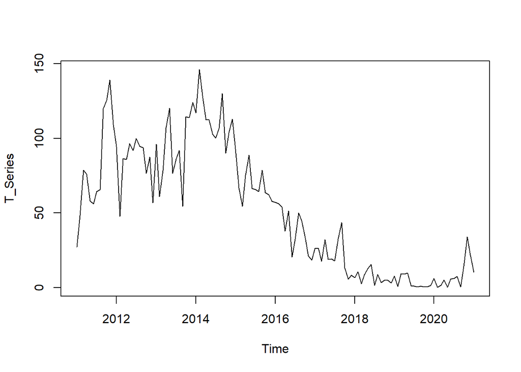

```r
plot(T_Series)
```

# Finding ACF

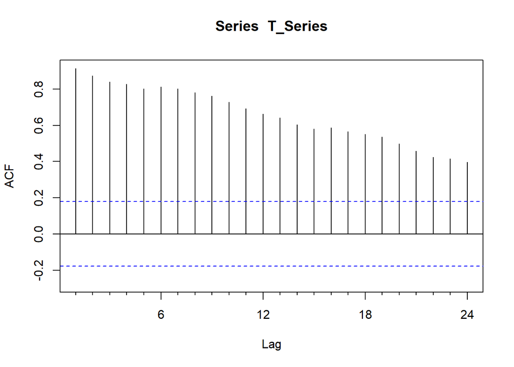

```r
Acf(T_Series)
```

# Understand and explain your model output

Trend is showing as a downward trend gradually over the period of time. The dataset is a 10 years monthly sunspot data and it’s showing a bit of seasonality in the ACF around 6 month and 18 month period.

# Average Method

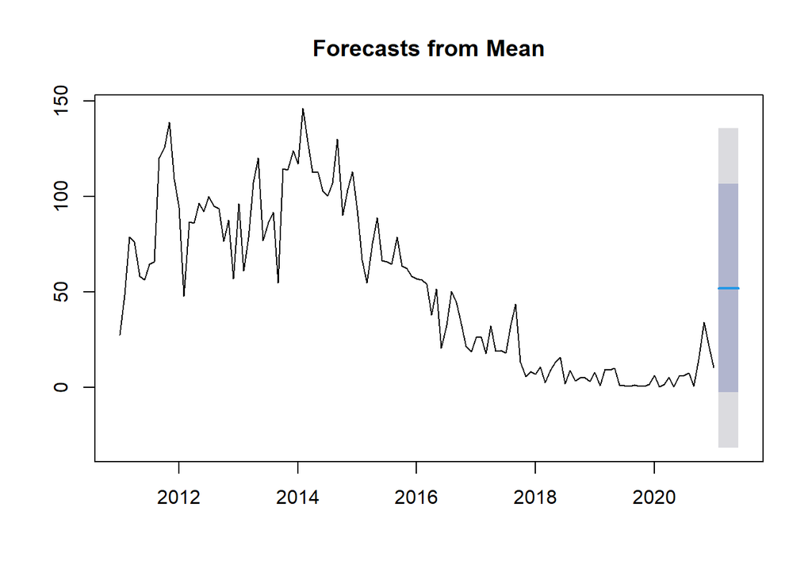

```r
mean_forecast <- meanf(T_Series,5)
plot(mean_forecast)
```

# Naive Method

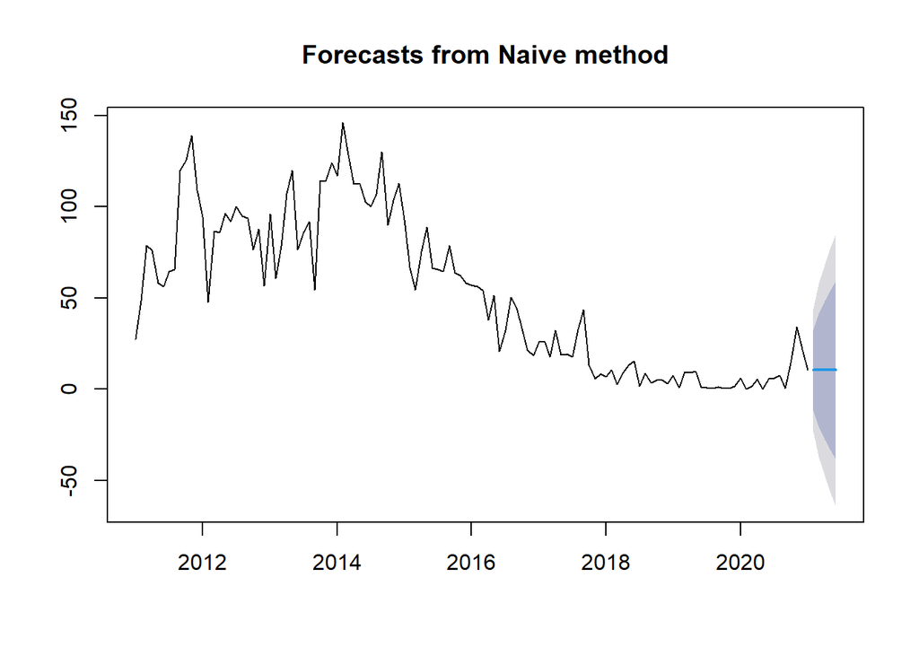

```r
naive_forecast <- naive(T_Series,5)
plot(naive_forecast)
```

This is a forecasting method where the most recent data point in a dataset is referred to make predictions for the future data points. Also known as the “no change forecast” method. It assumes that there will be no change or growth in the variable and that historical data is a reliable predictor of the future. The Naive Method is incredibly simple to use and understand. It requires minimal computation and can be applied quickly. The Naive Method assumes that the future will be the same as the most recent observation. Does not look very accurate in the Dataset used in the assignment as the output relies solely on the value of the sunspot measured in 2021.